```python
import numpy as np
import pandas as pd
import matplotlib
#matplotlib.use('Agg')
import matplotlib.pyplot as plt
import seaborn as sns
from sklearn.cluster import KMeans
from sklearn.preprocessing import StandardScaler
from sklearn.decomposition import PCA

from scipy.cluster import hierarchy
```

# 1-5 Hierarchical Clustering

1. The similarity between clusters in a hierachical cluster graph is based on the (Y-AXIS/height | X-AXIS/width), which represents the distance between cluster groups for a given # of clusters. Clusters that merge at higher values are (MORE | LESS) similar than clusters that merge at lower values.
2. The CSV file named 'automobiles.csv' is read into the Pandas Dataframe `df` for you below. The variables of `df` have been standardized and transformed according to their z-score, are stored into the numpy array Xdf.

Using scipy's hierarchy module, apply COMPLETE hierarchical clustering to `Xdf` and store the result into the variable `hclust`. Plot a dendrogram showing the complete linkage of `hclust`.

How many clusters is recommended (shown by the unique colors)?

```python
# STARTER
df = pd.read_csv("automobiles.csv")
df_features = df.select_dtypes("number").copy()

Xdf = StandardScaler().fit_transform(df_features)

# SOLUTION
hclust = hierarchy.complete( Xdf )
```

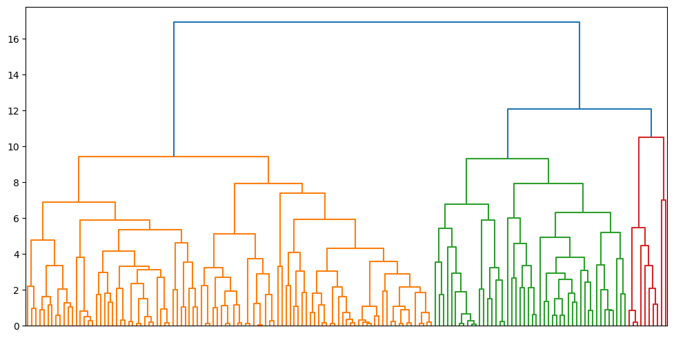

```python
fig = plt.figure(figsize=(12, 6))
hierarchy.dendrogram( hclust, no_labels = True)
plt.show()
```

#### How Many Clusters

We can see 3 clusters

3. The CSV file named 'automobiles.csv' is read into the Pandas Dataframe `df` for you below. The variables of `df` have been standardized and transformed according to their z-score, are are stored into the numpy array `Xdf`.

Using scipy's hierarchy module, apply CENTROID hierarchical clustering to `Xdf` and store the result into the variable `hclust`. Plot a dendrogram showing the centroid linkage clustering of `hclust`.

Compared to the COMPLETE dendrogram you generated in question 2, which of the following is true about the CENTROID dendrogram?

- The CENTROID dendrogram is dominated by a single cluster hierarchy while the COMPLETE dendrogram has multiple distinct cluster hierarchies
- Both dendrograms have the same hierarchical shape but merge at different distances
- The CENTROID dendrogram has a greater number of distinct cluster hierarchies

```python
# STARTER
df = pd.read_csv("automobiles.csv")
df_features = df.select_dtypes("number").copy()
Xdf = StandardScaler().fit_transform(df_features)

# SOLUTION
```

```python
hclust_centroid = hierarchy.centroid( Xdf )
```

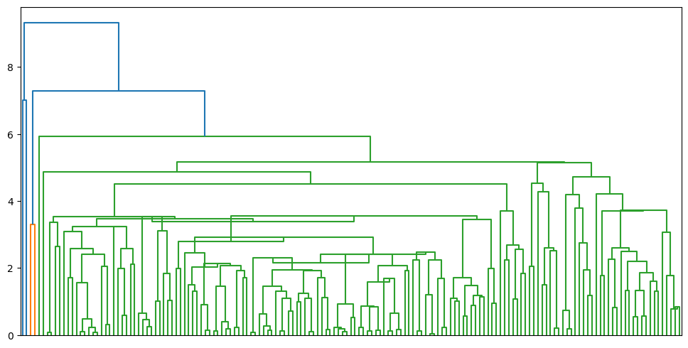

```python
fig = plt.figure(figsize=(12,6))
hierarchy.dendrogram(hclust_centroid, no_labels=True)
plt.show()
```

4. The CSV file named 'automobiles.csv' is read into the Pandas Dataframe `df` for you below. The variables of `df` have been standardized and transformed according to their z-score, are are stored into the numpy array `Xdf`.

Using scipy's hierarchy module, apply WARD hierarchical clustering to `Xdf` and store the result into the variable `hclust`. Manually set the height cutoff for distinct clusters to 15 with the `hierarchy.cut_tree()` method and store the result into `hclust_cut`. Using numpy, print the unique number of clusters within `hclust_cut`. Then, plot a dendrogram showing the ward linkage clustering of `hclust`. You must set the argument `color_threshold=15`.

How many distinct clusters are generated using a height of 15 for the WARD hierarchy?

```python
# STARTER
df = pd.read_csv("automobiles.csv")
df_features = df.select_dtypes("number").copy()
Xdf = StandardScaler().fit_transform(df_features)

# SOLUTION
```

```python
hclust_ward = hierarchy.ward( Xdf )
```

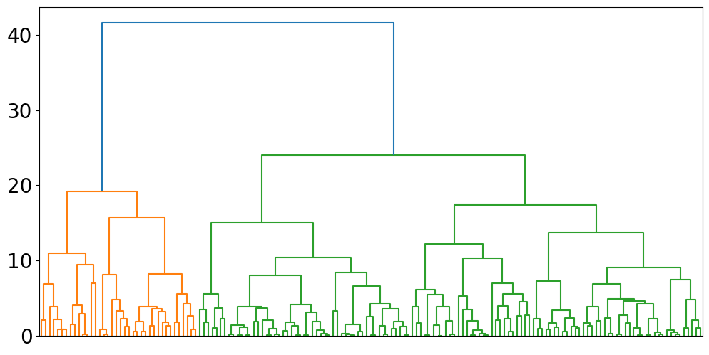

```python
fig = plt.figure (figsize=(12,6))
hierarchy.dendrogram(hclust_ward, no_labels = True)
plt.show()
```

```python
hclust_cut = hierarchy.cut_tree(hclust_ward, height=15).ravel()
```

```python
hclust_cut.shape
```

```
(159,)
```

#### 7 Clusters

```python
np.unique(hclust_cut)
```

```
array([0, 1, 2, 3, 4, 5, 6])
```

5. Matching
6. COMPLETE defines the distance between two clusters according to...
7. SINGLE defines the distance between two clusters according to...
8. AVERAGE defines the distance between two clusters according to...
9. CENTROID defines the distance between two clusters according to...
10. WARD defines the distance two between clusters according to...
- the maximum distance between observations (furthest pair)
- the minimum distance between observations (closest pair)
- the distance between each cluster's centroid
- the minimum within-cluster variance
- the average distance between all observations within a cluster

# 6-8 PCA

6. Which of the following is true about using PCA?
- It reduces the dimensionality (# of variables) of a dataset
- It is used to simplify and summarize the important features of a dataset
- Principal components are generated in such a way that pc1 has the MOST variability and subsequent pcs have decreasing variability
- PCA can only be applied to numerical features
- PCA combines correlated variables into shared principle components
7. The CSV file named 'automobiles.csv' is read into the Pandas Dataframe `df` for you below.

Using SEABORN, plot a heatmap showing the correlation matrix between all numeric variables in `df`. You must set the arguments `vmin=-1` and `vmax=1` within heatmap.

According to the correlation matrix:

- Horsepower has a ___ correlation with city_mpg and highway_mpg
- Stroke has a ___ correlation with peak_rpm
- Curb weight has a ___ correlation with price

```python
# STARTER
df = pd.read_csv("automobiles.csv")
```

```python
df.info()
```

```
<class 'pandas.core.frame.DataFrame'>
RangeIndex: 159 entries, 0 to 158
Data columns (total 26 columns):
 #   Column             Non-Null Count  Dtype
---  ------             --------------  -----
 0   risk_symboling     159 non-null    int64
 1   normalized_losses  159 non-null    float64
 2   make               159 non-null    object
 3   fuel_type          159 non-null    object
 4   aspiration         159 non-null    object
 5   doors              159 non-null    float64
 6   body_style         159 non-null    object
 7   drive              159 non-null    object
 8   engine_location    159 non-null    object
 9   wheel_base         159 non-null    float64
```

[output cut: 18 more lines]

```python
features = df.select_dtypes(include='number')
```

```python
features.info()
```

```
<class 'pandas.core.frame.DataFrame'>
RangeIndex: 159 entries, 0 to 158
Data columns (total 18 columns):
 #   Column             Non-Null Count  Dtype
---  ------             --------------  -----
 0   risk_symboling     159 non-null    int64
 1   normalized_losses  159 non-null    float64
 2   doors              159 non-null    float64
 3   wheel_base         159 non-null    float64
 4   length             159 non-null    float64
 5   width              159 non-null    float64
 6   height             159 non-null    float64
 7   curb_weight        159 non-null    int64
 8   cylinders          159 non-null    int64
 9   engine_size        159 non-null    int64
 10  bore               159 non-null    float64
 11  stroke             159 non-null    float64
 12  compression_ratio  159 non-null    float64
 13  horsepower         159 non-null    float64
 14  peak_rpm           159 non-null    float64
 15  city_mpg           159 non-null    int64
 16  highway_mpg        159 non-null    int64
 17  price              159 non-null    float64
dtypes: float64(12), int64(6)
memory usage: 22.5 KB
```

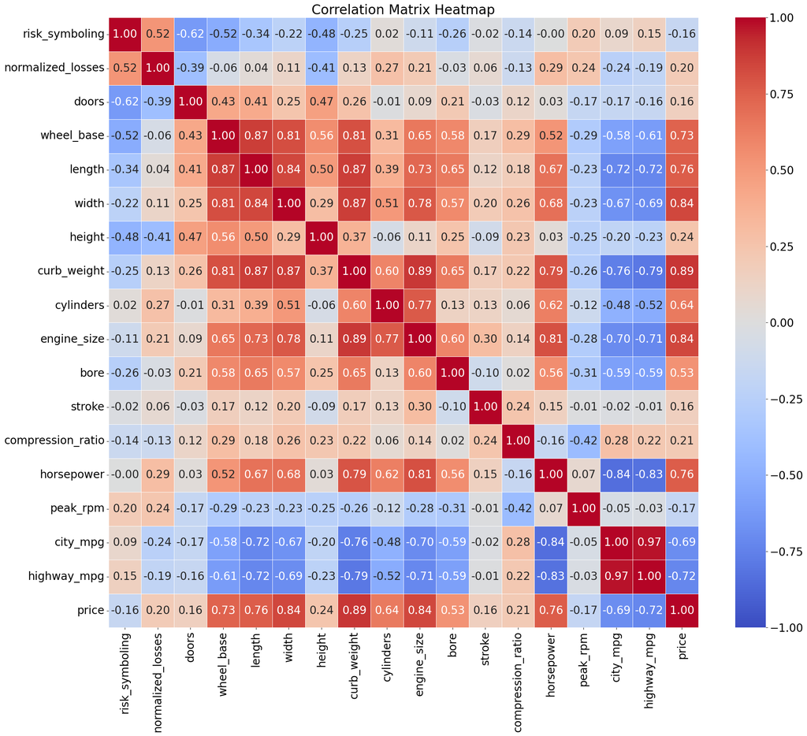

```python
correlation_matrix = features.corr()

plt.rcParams.update({'font.size': 20})
plt.figure(figsize=(24,20))

sns.heatmap(correlation_matrix, annot=True, cmap='coolwarm', fmt=".2f", linewidths=0.5, vmin=-1 , vmax=1,
           center=0, annot_kws={"size": 20})

plt.title("Correlation Matrix Heatmap")
```

### Correlation

8. Using the same graph you generated in question 7, which dataset features would be likely to be combined into the same principle components (variables that are similarly correlated)?
- A `length`, `width`, `height`, `wheel base` and `curbweight` are likely to be combined into a principal component relating to the overall "size" of the vehicle
- A `city_mpg` and `highway_mpg` are likely to be combined into a principal component relating to the overall "efficiency" of the vehicle
- `stroke`, `bore`, `peak_rpm` and `compression ratio` are likely to be combined into a principal component relating to the "engine" type

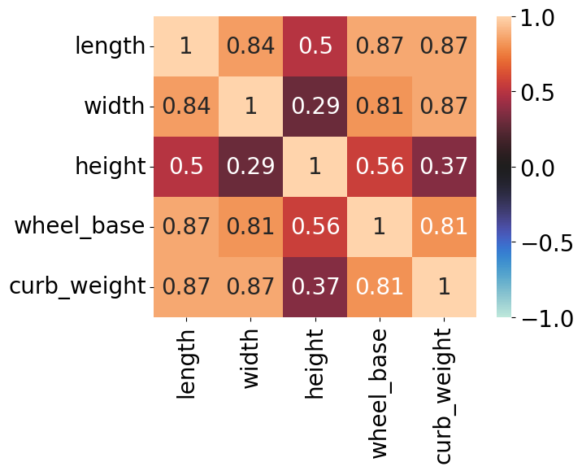

```python
features1 = df[['length', 'width', 'height', 'wheel_base', 'curb_weight']]
corr1=features1.corr()
sns.heatmap(corr1, annot=True, cmap='icefire', vmin=-1, vmax=1, center=0)
```

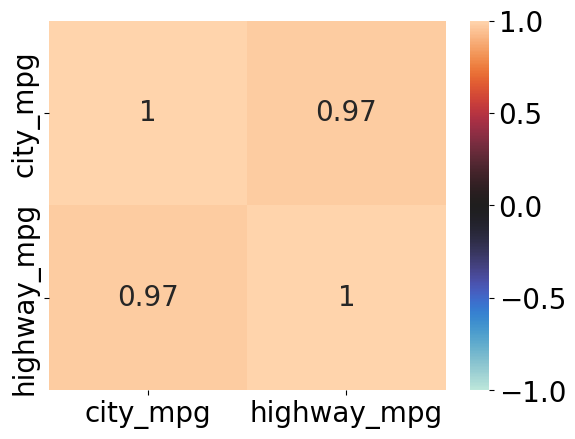

```python
features2=df[['city_mpg', 'highway_mpg']]
corr2 = features2.corr()
sns.heatmap(corr2, annot=True, vmin=-1, vmax=1, center=0, cmap='icefire')
```

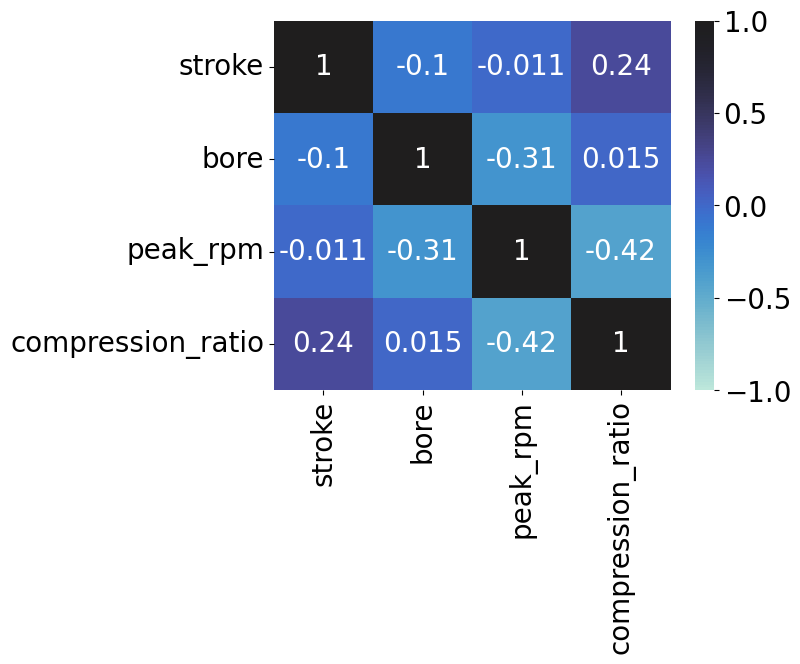

```python
features3=df[['stroke', 'bore', 'peak_rpm', 'compression_ratio']]
corr3=features3.corr()
sns.heatmap(corr3, annot=True, vmin=-1, vmax=1, center=1, cmap='icefire')
```

### Based on 7 Clusters resulting from cut at height 15

```python
hclust_cut.shape
```

```
(159,)
```

```python
np.unique(hclust_cut)
```

```
array([0, 1, 2, 3, 4, 5, 6])
```

```python
pca_auto = PCA(n_components=2).fit_transform(Xdf)
```

```python
pca_auto.shape
```

```
(159, 2)
```

```python
pca_auto_df = pd.DataFrame(pca_auto, columns=['pc01','pc02'])
```

```python
pca_auto_df
```

|  | pc01 | pc02 |
| --- | --- | --- |
| 0 | 0.348023 | 0.822911 |
| 1 | 2.229092 | 1.867665 |
| 2 | 3.801903 | 0.607839 |
| 3 | 4.811203 | 1.046030 |
| 4 | 0.368747 | 2.041817 |
| ... | ... | ... |
| 154 | 3.565058 | -1.637500 |
| 155 | 4.503400 | -1.085507 |
| 156 | 5.209260 | -0.308763 |
| 157 | 4.165003 | -2.028251 |
| 158 | 4.279425 | -1.398708 |

159 rows × 2 columns

```python
pca_auto_df['hclust_7']=pd.Series(hclust_cut, index=(pca_auto_df.index).astype('category'))
```

```python
pca_auto_df
```

|  | pc01 | pc02 | hclust_7 |
| --- | --- | --- | --- |
| 0 | 0.348023 | 0.822911 | 0 |
| 1 | 2.229092 | 1.867665 | 0 |
| 2 | 3.801903 | 0.607839 | 1 |
| 3 | 4.811203 | 1.046030 | 1 |
| 4 | 0.368747 | 2.041817 | 0 |
| ... | ... | ... | ... |
| 154 | 3.565058 | -1.637500 | 1 |
| 155 | 4.503400 | -1.085507 | 1 |
| 156 | 5.209260 | -0.308763 | 2 |
| 157 | 4.165003 | -2.028251 | 5 |
| 158 | 4.279425 | -1.398708 | 1 |

159 rows × 3 columns

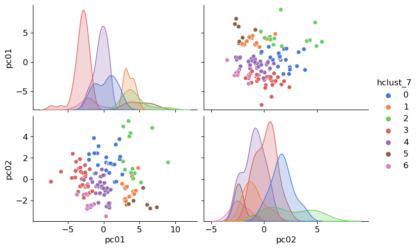

```python
plt.rcParams.update({'font.size':12})
sns.pairplot(pca_auto_df, hue='hclust_7', palette='muted', aspect=1.5)
```

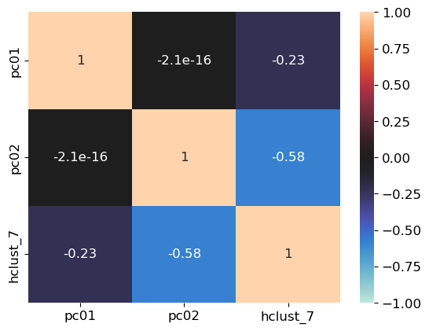

```python
corr_matrix = pca_auto_df.corr()
sns.heatmap(corr_matrix, annot=True, vmin=-1, vmax=1, center=0)
```

```python
pca_auto_df['price']=df['price']
```

```python
pca_auto_df
```

|  | pc01 | pc02 | hclust_7 | price |
| --- | --- | --- | --- | --- |
| 0 | 0.348023 | 0.822911 | 0 | 13950.0 |
| 1 | 2.229092 | 1.867665 | 0 | 17450.0 |
| 2 | 3.801903 | 0.607839 | 1 | 17710.0 |
| 3 | 4.811203 | 1.046030 | 1 | 23875.0 |
| 4 | 0.368747 | 2.041817 | 0 | 16430.0 |
| ... | ... | ... | ... | ... |
| 154 | 3.565058 | -1.637500 | 1 | 16845.0 |
| 155 | 4.503400 | -1.085507 | 1 | 19045.0 |
| 156 | 5.209260 | -0.308763 | 2 | 21485.0 |
| 157 | 4.165003 | -2.028251 | 5 | 22470.0 |
| 158 | 4.279425 | -1.398708 | 1 | 22625.0 |

159 rows × 4 columns

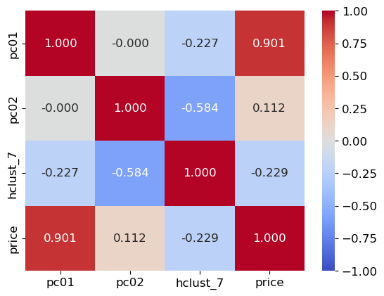

```python
corr_price = pca_auto_df.corr()
sns.heatmap(data=corr_price, annot=True, vmin=-1, vmax=1, center=0, cmap='coolwarm', fmt='.3f', annot_kws={'size':12})
```

### Based on 3 Clusters

```python
hclust_ward.shape
```

```
(158, 4)
```

```python
hclust_3 = hierarchy.cut_tree(hclust_ward, n_clusters=3).ravel()
```

```python
hclust_3.shape
```

```
(159,)
```

```python
np.unique(hclust_3)
```

```
array([0, 1, 2])
```

```python
pca_auto_df['hclust_3']=pd.Series(hclust_3, index=pca_auto_df.index)
```

```python
pca_auto_df.info()
```

```
<class 'pandas.core.frame.DataFrame'>
RangeIndex: 159 entries, 0 to 158
Data columns (total 5 columns):
 #   Column    Non-Null Count  Dtype
---  ------    --------------  -----
 0   pc01      159 non-null    float64
 1   pc02      159 non-null    float64
 2   hclust_7  159 non-null    int64
 3   price     159 non-null    float64
 4   hclust_3  159 non-null    int64
dtypes: float64(3), int64(2)
memory usage: 6.3 KB
```

```python
corr_hc3 = pca_auto_df[['pc01','pc02','hclust_3','hclust_7','price']].corr()
```

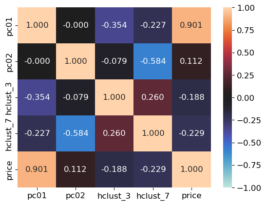

```python
sns.heatmap(data=corr_hc3, annot=True, fmt='.3f', vmin=-1, vmax=1, center=0, cmap='icefire')
```

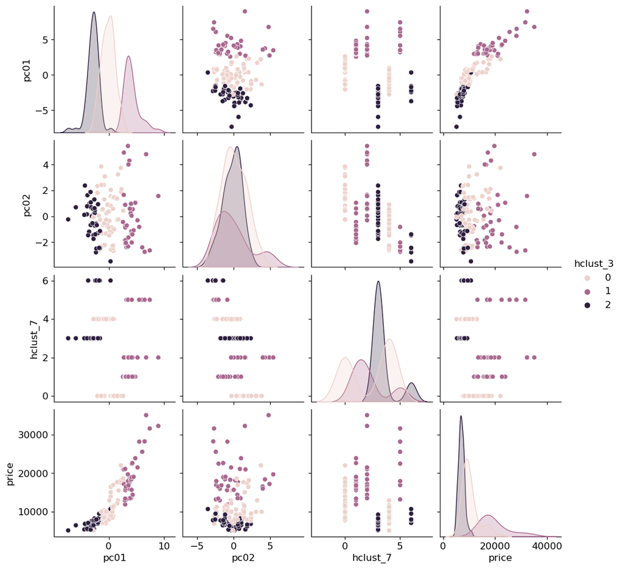

```python
sns.pairplot(data=pca_auto_df, hue='hclust_3')
```

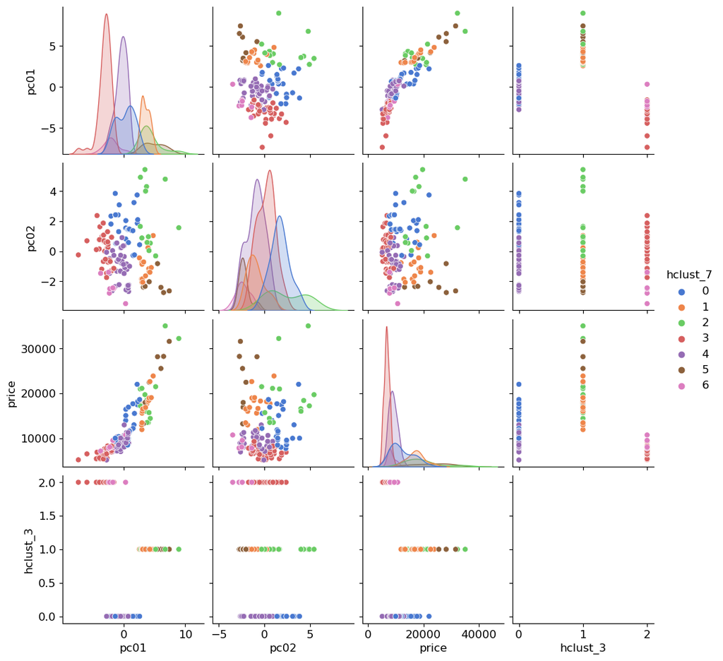

```python
sns.pairplot(data=pca_auto_df, hue='hclust_7', palette='muted')
```

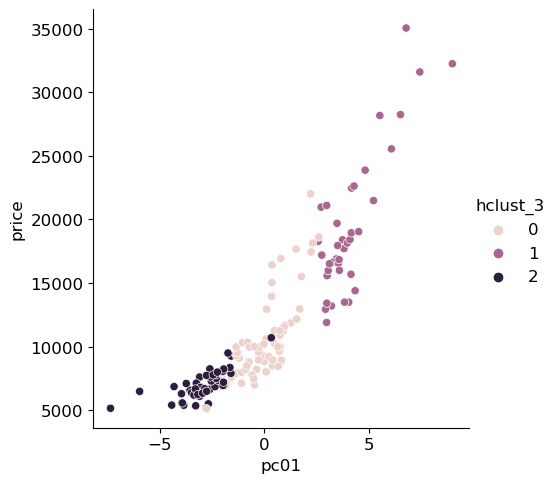

```python
sns.relplot(pca_auto_df, x='pc01', y='price', hue='hclust_3')
```

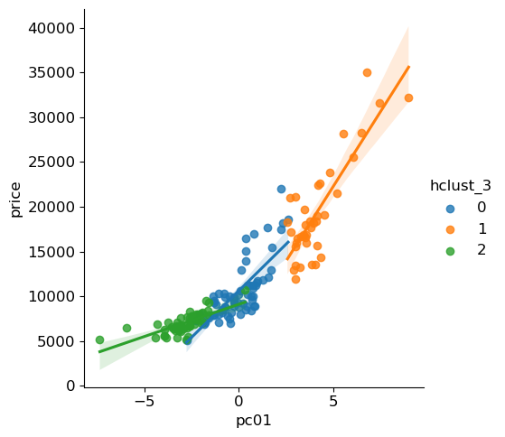

```python
sns.lmplot(pca_auto_df, x='pc01', y='price', hue='hclust_3')
```

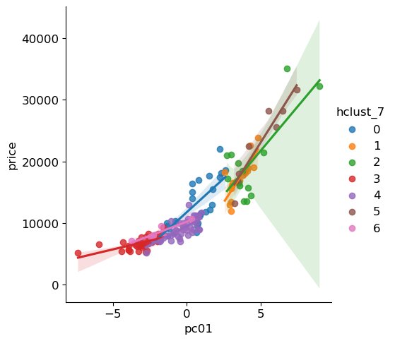

```python
sns.lmplot(pca_auto_df, x='pc01', y='price', hue='hclust_7')
```